# Figures_Sendra2023

#### Create heatmap for given feature/peak ranges

Visualize and compare the binding patterns of raw signals of multiple ChIP-Seq experiments using function featureAlignedHeatmap and featureAlignedDistributio from package ChipSeqAnno

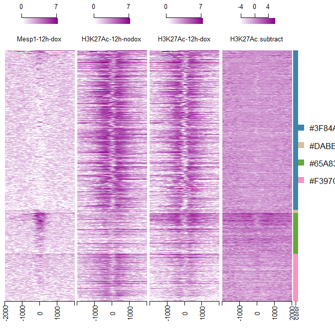

```r
chip_bigwig_path <- file.path(data, "other_publications", "Lin2022_ChipSeq_ESC_Mesp1_dox")
chip_files <- list.files(chip_bigwig_path)

# Change names to filenames without extention
names(sig_n) <- gsub(".bw", "", chip_files)

# Calculate a new slot for the difference between H3K27Ac-12hdox (+Mesp1 induction) and H3K27Ac-12hnodox
sig_n$H3K27Ac.subtract <- sig_n$`H3K27Ac-12h-dox` - sig_n$`H3K27Ac-12h-nodox`

# You can specify exactly what tracks you want to plot. We can plot them all by doing his
keep <- names(sig_n)  # select all names

# use this to select the ones you want or change order
keep <- c("Mesp1-12h-dox", "H3K27Ac-12h-nodox","H3K27Ac-12h-dox", "H3K27Ac.subtract")

# Create new column in metadata named color that maps the cluster. PURPLE
feature.recentered$color <- color.epiblast.named[as.character(marker_peaks_log2FC0.5$cluster)]

heatmap <- featureAlignedHeatmap(sig_n[keep], feature.recentered,
                                 upstream=2000, downstream=2000,
                                 annoMcols = "color", gap = 0.01,
                                 color = grDevices::colorRampPalette(c("white", "magenta4"))(50),
                                 # lower.extreme = c(0, 0, 0, 0),
                                 # sortBy = # Default is that all strips are ordered according to the signal of the first one
                                 # upper.extreme = c(7, 7, 7, max(sig_n$subtract))
                                 )
```

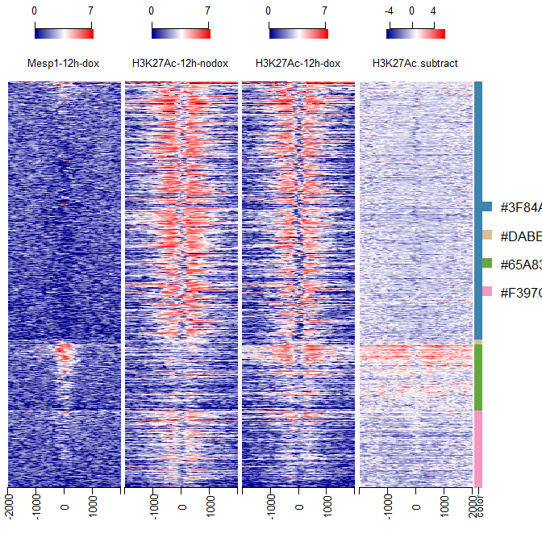

```r
# Save in svg as well because we need to move around text and make axis more beautiful in Adobe illustrator
heatmap %>% ggsave(file.path(figures, "stripplot_Mesp1_H3K27Ac_chip_subtract_purple.png"), plot = ., width = 6, height = 5, units = "in")
heatmap %>% ggsave(file.path(figures, "stripplot_Mesp1_H3K27Ac_chip_subtract_purple.svg"), plot = ., width = 6, height = 5, units = "in")

# Create new column in metadata named color that maps the cluster. PURPLE
heatmap <- featureAlignedHeatmap(sig_n[keep], feature.recentered,
                                 upstream=2000, downstream=2000,
                                 annoMcols = "color", gap = 0.01,
                                 color = grDevices::colorRampPalette(c("darkblue","white", "red2"))(50),
                                 # lower.extreme = c(0, 0, 0, 0),
                                 # sortBy = # Default is that all strips are ordered according to the signal of the first one
                                 # upper.extreme = c(7, 7, 7, max(sig_n$subtract))

                                 )
```

```r
heatmap %>% ggsave(file.path(figures, "stripplot_Mesp1_H3K27Ac_chip_subtract_darkblue_red2.png"), plot = ., width = 6, height = 5, units = "in")
heatmap %>% ggsave(file.path(figures, "stripplot_Mesp1_H3K27Ac_chip_subtract_darkblue_red2.svg"), plot = ., width = 6, height = 5, units = "in")
```

#### Plotting distributions of aligned signals to summarize what is seen in each column of the stripplot.

There is no way to separate diferent chips on featureAlignedDistribution (as far as I know) So we will iterate over each chip data item in sig_n and plot the distributions separated by cluster.

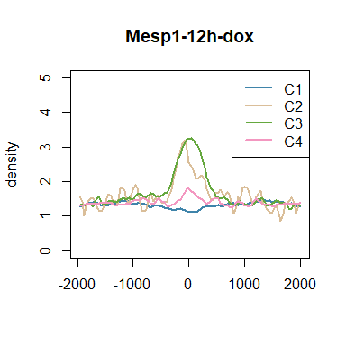

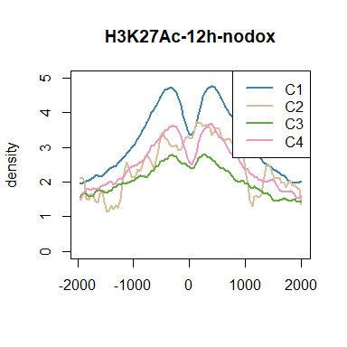

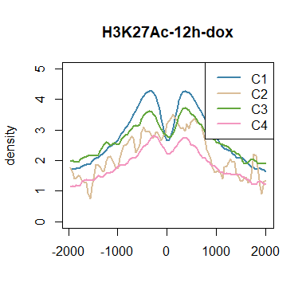

```r
# same scales for all plots helps comparing the different chips
ylim_max <- 5

clusters <- unique(feature.recentered$cluster)
# change order
sig_n <- sig_n[keep]

for (chip in names(sig_n)) {
  # Select one chip at a time
  sig_n.chip <- sig_n[[chip]]

  # Create a list to store subsets
  subset_list <- list()

  # Subset sig_n matrix for each cluster and store in the list
  for (cluster in clusters) {
    indices <- which(feature.recentered$cluster == cluster)
    subset_list[[cluster]] <- sig_n.chip[indices, ]
  }

  suppressWarnings(
  distribution <- featureAlignedDistribution(subset_list, feature.recentered,
                           upstream=2000, downstream=2000,
                           type="l", col = color.epiblast.named[2:5],
                           main = chip, # plot title
                           ylim = c(0, ylim_max), # common limit for all chips helps visualize better the change (Same scale)
                           lwd = 2,    # Line width
                           lty = 1)  # Line type
  )
  # Save plots
  # dev.print(svg, file = file.path(figures, paste0("distribution_", chip, ".svg")), width = 3, height = 3)
  # dev.off()  # Close the SVG device
}
```

[figure not shown]

```r
NA
```

```r
gene_list
```

```
[1] "Nfatc1, Rftn1, Pla2g6, Erc2, Tenm4, Notch1, Itga6, Gm20388, Rimbp2, Rasgrp3, Fam120b, Snai1, Aplnr, Pex26, Zfp36l2, Braf, Dgkg, Limch1, S1pr5, Mrps33, Pdgfra, Tenm4, Rai14, Ptp4a3, Vxn, Klhl42, Gpc5, Fn1, Wdtc1, Sp5, Slc43a1, Col13a1, Bcl2l1"
```

### B Motif enrichment analysis with Chromvar

Calculated previously. data/snATACseq_preprocessing_report

```r
# Load data with enriched motifs calculated with ChromVar
motif_enrichment <- readRDS(file.path(data, "snATACseq", "motifs.DEvsAll.peaks.Epiblast2.All.peaks_snn_res.0.5.mod.5.LR.rds"))

# The excel contains all motifs in all cluster
# First filter significant ones to get the marker motifs

# Filter significant motifs
significant_motifs <- motif_enrichment %>%
  filter(p.adjust < 0.05)

# Count the number of clusters each motif is associated with
motif_counts <- significant_motifs %>%
  group_by(motif) %>%
  summarise(num_clusters = n_distinct(cluster))

# Filter motifs exclusive to one cluster
exclusive_motifs <- motif_counts %>%
  filter(num_clusters == 1) %>%
  pull(motif)

# Filter rows in motif_enrichment based on exclusive_motifs
exclusive_enrichment <- significant_motifs %>%
  filter(motif %in% exclusive_motifs)

# Order result by fold.enrichment within each cluster
exclusive_enrichment_ordered <- exclusive_enrichment %>%
  arrange(cluster, desc(fold.enrichment))

# Write the ordered enrichment to a CSV file
write.csv(exclusive_enrichment_ordered, file.path(results, "exclusive_TF_motif_enrichment_ordered.csv"))

# Print top 3 of each cluster
exclusive_enrichment_ordered %>%
  group_by(cluster) %>%
  slice_head(n = 3)
```

[output not shown]

#### Plot top motif for every cluster

[figure not shown]

```r
top_n <- 4

# Get unique clusters
clusters <- unique(exclusive_enrichment_ordered$cluster)

# Initialize a list to store individual plots
plot_list <- list()

# Loop through each cluster
for (cluster_id in clusters) {

  # Extract top motifs for the current cluster
  marker_motifs <- exclusive_enrichment_ordered %>%
    filter(cluster == cluster_id) %>%
    head(n = top_n)  %>%
    pull(motif)


  marker_names <- exclusive_enrichment_ordered %>%
    filter(cluster == cluster_id) %>%
    head(n = top_n) %>%
    pull(motif.name)


  # Create FeaturePlot for the current cluster
  p <- snATAC %>%
    FeaturePlot(features = marker_motifs, min.cutoff = 'q10', max.cutoff = 'q90') & NoLegend() & NoAxes()

  # Change titles for gene names on each feature of the featureplot
  for (i in 1:length(marker_names)) p[[i]]$labels$title = marker_names[i]

  # Add the current cluster's plot to the list
  plot_list[[length(plot_list) + 1]] <- p

}
# Arrange the plots in a grid
grid_arrange <- plot_list %>%
  grid.arrange(grobs = ., ncol = 2)
```

```r
# Save the combined grid plot
ggsave(file.path(figures, "Top_enriched_motifs_per_cluster.png"), plot = grid_arrange, dpi = 600, width = 6, height = 6)
```

#### Plot top expressed

selected representative for each cluster, considering its expression at this stage in other scRNAseq datasets

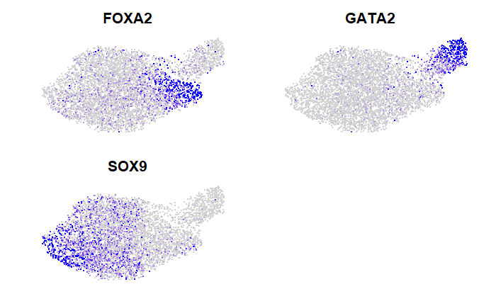

```r
# Write here the TF which motif enrichment you want to plot
top_selected_names <- c("FOXA2", "GATA2", "SOX9")

top_selected_motifs <- exclusive_enrichment %>%
  filter(motif.name %in% top_selected_names) %>%
  pull(motif)

p <- snATAC %>%
  FeaturePlot(features = top_selected_motifs, min.cutoff = 'q10', max.cutoff = 'q90') & NoLegend() & NoAxes()
# Change titles for gene names on each feature of the featureplot
for (i in 1:length(top_selected_names)) p[[i]]$labels$title = top_selected_names[i]

p

# Save the combined grid plot
ggsave(file.path(figures, "Top_enriched_selected_motifs_per_cluster.png"), plot = p, dpi = 600, width = 6, height = 6)
```